# PopGen Chapter 2: Genotype Frequencies

August 31, 2015

## Chapter 1: Thinking like a population geneticist

**population genetics**: is a dialog between predictions based on principles of Mendelian inheritance and results obtained from empirical measurement of genotype and allele freq that form the basis of hypothesis tests.

- Expectations
- Theory and assumptions
- Simulation

## 2.1 Mendel’s model of particulate genetics

- Mendel’s first law (Aa): independent segregation of alleles at a single locus  
  random sampling without bias

```r
chisq.test(table(rbinom(1000, 1, p=0.5)+rbinom(1000, 1, p=0.5)), c(1,2,1))
```

```
##
##  Pearson's Chi-squared test
##
## data:  table(rbinom(1000, 1, p = 0.5) + rbinom(1000, 1, p = 0.5)) and c(1, 2, 1)
## X-squared = 3, df = 2, p-value = 0.2231
```

- Mendel’s second law (AaBb): independent assortment of multiple loci  
  independent (apply the product rule)

## 2.2 Hardy-Weinberg expected genotype freq

- HW and its assumptions
- Each assumption is a popgen process
- HW is a null model
- HW in haplo-diploid systems?

```r
geno <- as.data.frame(t(sapply(1:999/1000,
                               function(x){ return(c(x^2,2*x*(1-x),(1-x)^2))})))
plot(1:999/1000, geno[,1], type="l", lty=2, lwd=2, col="red",
     xlab="Allele Freq (p)", ylab="Genotype Freq")
lines(1:999/1000, geno[,2], type="l", lty=1, lwd=2, col="blue")
lines(1:999/1000, geno[,3], type="l", lty=3, lwd=2, col="green")
```

## 2.2 Hardy-Weinberg expected genotype freq

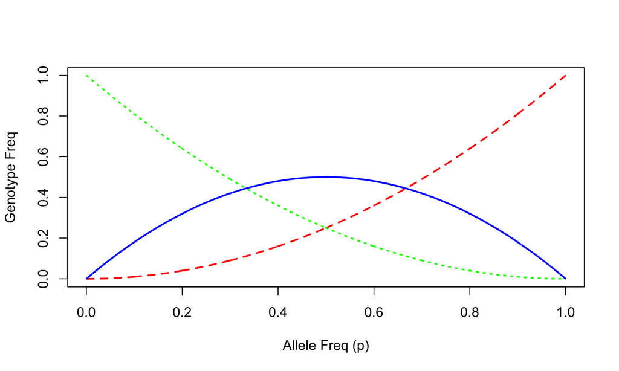

## 2.3 Why does HW work?

- A simple proof of HW
- HW with more than two alleles

HW equation: \(p^2 + 2pq + q^2 =1\)  
HW equilibrium: \(f(A)_t = f(A)_{t+1}\)

genotype freq remain constant over generations as long as the assumptions of HW are met.

## 2.4 Applications of HW

- apply HW to estimate the freq of an observed genotype in a forensic DNA typing case
- The \(\chi^2\) test gauges whether observed and expected differ more than expected by chance

Chisq test provides the probability of obtaining the difference between the observed and expected number of outcomes by chance alone if the null hypothesis is true.

- Assume HW to compare two genetic models

## 2.5 The fixation index and heterozygosity

- The fixation index (F) measures deviation from HW expected heterozygote freq

\(F = (H_e - H_o) / H_e\)

**fixation index (F)**: used to compare how much heterozygosity is present in an actual population relative to expected levels of heterozygosity under random mating.

Negative values indicate heterozygote excess and positive values indicate homozygote excess relative to HW expectation.

## 2.5 The fixation index and heterozygosity

- Examples of mating systems and F in wild populations
- Observed and expected heterozygosity

**positive assortative mating**: individuals with like genotypes or phenotypes tend to mate  
**negative assortative mating**: individuals with unlike genotypes or phenotypes tend to mate  
**Consanguineous mating or biparental inbreeding**: mating among related individuals

## 2.6 Mating among relatives

- Consanguineous mating **alters genotype freq but not allele freq**

Impacts of inbreeding on genotype and allele freq

Inbreeding causes alleles to be packaged more frequently as homozygotes (heterozygosity declines) and inbreeding does not alter allele freq in a population.

## 2.6 Mating among relatives

- Mating among relatives and the probability that two alleles are identical by descent

**autozygous**: a homozygous genotype composed of two identical alleles that are inherited from a common ancestor  
**allozygout**: a homozygous or heterozygous genotype composed of two alleles not inherited from a recent common ancestor  
**degree of relatedness**: the expected proportion of alleles between two individuals that are identical by descent; twice the autozygosity.  
**coefficient of inbreeding (f)**: the probability that two alleles in a homozygous genotype are identical by descent.

The inbreeding coefficient and the fixation index are measures of excess homozygosity and therefore are just different ways of expressing the heterozygosity.

## 2.6 Mating among relatives

- Inbreeding depression and its possible causes

Phenotypic consequences of inbreeding In plants, traits early in the life cycle such as germination less often show inbreeding depression?

- The many meaning of inbreeding  
  the term “inbreeding"

## 2.7 Gametic disequilibrium (or LD?)

- Estimating gametic disequilibrium with D
- Approach to gametic equilibrium over time
- Causes of gametic disequilibrium

Processes that maintain or increase gametic disequilibrium  
1. Physical linkage  
2. Natural selection  
3. Mutation  
4. Mixing of diverged populations  
5. mating system  
6. Chance